# Psych 251 PS4: Simulation + Analysis

Mike Frank, homework solutions by Philip Hernandez

2019

This is problem set #4, in which we want you to integrate your knowledge of data wrangling with some basic simulation skills. It’s a short problem set to help consolidate your `ggplot2` skills and then help you get your feet wet in testing statistical concepts through “making up data” rather than consulting a textbook or doing math.

For ease of reading, please separate your answers from our text by marking our text with the `>` character (indicating quotes).

# Part 1: ggplot practice

This part is a warmup, it should be relatively straightforward `ggplot2` practice.

```r
library(tidyverse)
```

```r
library(ggplot2)
```

Load data from Frank, Vul, Saxe (2011, Infancy), a study in which we measured infants’ looking to hands in moving scenes. There were infants from 3 months all the way to about two years, and there were two movie conditions (`Faces_Medium`, in which kids played on a white background, and `Faces_Plus`, in which the backgrounds were more complex and the people in the videos were both kids and adults). An eye-tracker measured children’s attention to faces. This version of the dataset only gives two conditions and only shows the amount of looking at hands (other variables were measured as well).

```r
fvs <- read_csv("data/FVS2011-hands.csv")
head(fvs)
```

```
## # A tibble: 6 x 4
##   subid   age condition    hand.look
##   <dbl> <dbl> <chr>            <dbl>
## 1     2  3.16 Faces_Medium    0.0319
## 2    93  5.03 Faces_Medium    0.119
## 3    29  5.85 Faces_Medium    0.0921
## 4    76  5.85 Faces_Medium    0.130
## 5    48  6.08 Faces_Medium    0.0138
## 6   101  6.15 Faces_Medium    0.0438
```

First, use `ggplot` to plot a histogram of the ages of children in the study. NOTE: this is a repeated measures design, so you can’t just take a histogram of every measurement.

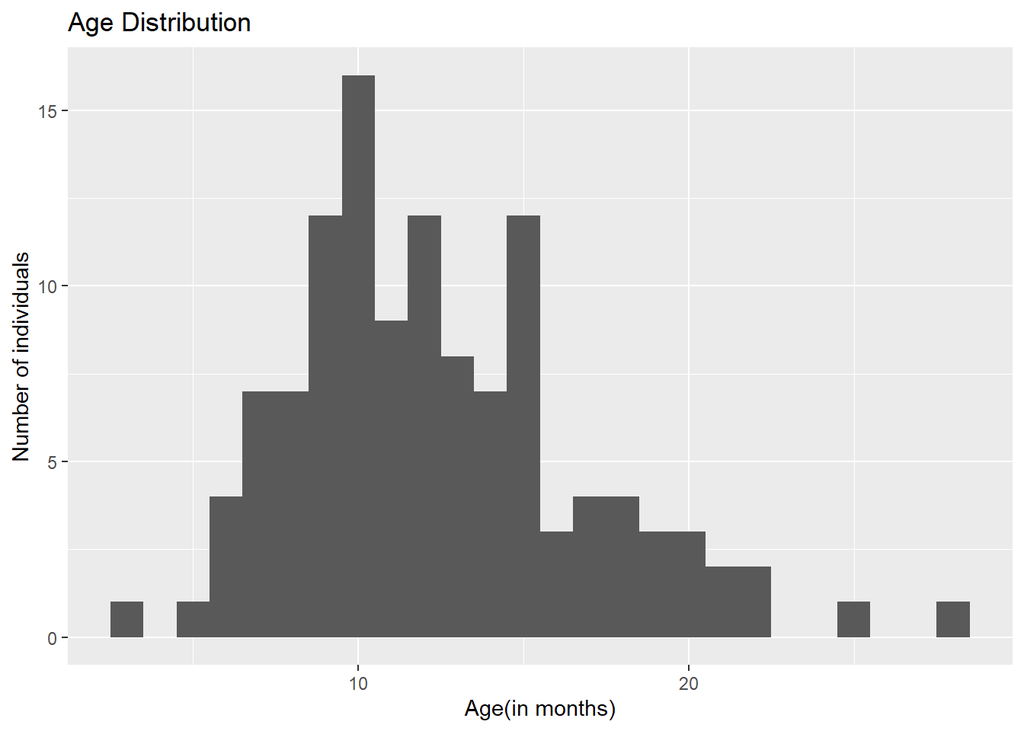

```r
fvs_unique <- fvs

fvs_unique <- distinct(fvs_unique, fvs_unique$subid, .keep_all = TRUE) #look for distinct values of subid

ggplot(fvs_unique, aes(age))+
  geom_histogram(binwidth=1) +
  labs(title = "Age Distribution ", x = "Age(in months)", y = "Number of individuals")
```

Second, make a scatter plot showing hand looking as a function of age and condition. Add appropriate smoothing lines. Take the time to fix the axis labels and make the plot look nice.

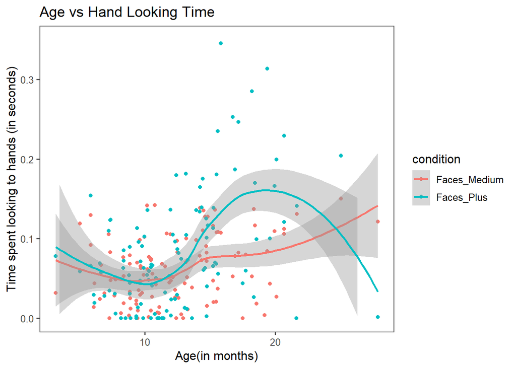

```r
ggplot(fvs, aes(age, hand.look)) +
  geom_point(aes(color = condition)) +
  geom_smooth(aes(color = condition)) +
  labs(title = "Age vs Hand Looking Time ", x = "Age(in months)", y = "Time spent looking to hands (in seconds)") +
  ggthemes::theme_few() +
  ylim(0,0.35)
```

What do you conclude from this pattern of data?

> The data suggest that after about the age of 12 months until 20 months, infants spent more time looking to hands in the Faces_Plus condition than in the Faces_Medium condition. Given the sparse sampling after 20 months and before 6 months, it is inappropriate to draw conclusions of those values.

What statistical analyses would you perform here to quantify these differences?

> I would conduct a regression analysis of the data, excluding the tails of the data where data is sparse. Using Hypothesis testing, this would allow me to determine whether the coefficients of the two conditions differ significantly.

```r
ctl <- c(4.17,5.58,5.18,6.11,4.50,4.61,5.17,4.53,5.33,5.14)
trt <- c(4.81,4.17,4.41,3.59,5.87,3.83,6.03,4.89,4.32,4.69)
group <- gl(2, 10, 20, labels = c("Ctl","Trt"))
weight <- c(ctl, trt)
lm.D9 <- lm(weight ~ group)
lm.D90 <- lm(weight ~ group - 1) # omitting intercept

anova(lm.D9)
```

```
## Analysis of Variance Table
##
## Response: weight
##           Df Sum Sq Mean Sq F value Pr(>F)
## group      1 0.6882 0.68820  1.4191  0.249
## Residuals 18 8.7292 0.48496
```

```r
summary(lm.D90)
```

```
##
## Call:
## lm(formula = weight ~ group - 1)
##
## Residuals:
##     Min      1Q  Median      3Q     Max
## -1.0710 -0.4938  0.0685  0.2462  1.3690
##
## Coefficients:
##          Estimate Std. Error t value Pr(>|t|)
## groupCtl   5.0320     0.2202   22.85 9.55e-15 ***
## groupTrt   4.6610     0.2202   21.16 3.62e-14 ***
## ---
## Signif. codes:  0 '***' 0.001 '**' 0.01 '*' 0.05 '.' 0.1 ' ' 1
##
## Residual standard error: 0.6964 on 18 degrees of freedom
## Multiple R-squared:  0.9818, Adjusted R-squared:  0.9798
## F-statistic: 485.1 on 2 and 18 DF,  p-value: < 2.2e-16
```

# Part 2: Simulation

```r
library(tidyverse)
```

Let’s start by convincing ourselves that t-tests have the appropriate false positive rate. Run 10,000 t-tests with standard, normally-distributed data from a made up 30-person, single-measurement experiment (the command for sampling from a normal distribution is `rnorm`).

The goal of these t-tests are to determine, based on 30 observations, whether the underlying distribution (in this case a normal distribution with mean 0 and standard deviation 1) has a mean that is different from 0. In reality, the mean is not different from 0 (we sampled it using `rnorm`), but sometimes the 30 observations we get in our experiment will suggest that the mean is higher or lower. In this case, we’ll get a “significant” result and incorrectly reject the null hypothesis of mean 0.

What’s the proportion of “significant” results ($p < .05$) that you see?

First do this using a `for` loop.

```r
outcome = numeric(10000)

for (i in 1:10000){

  sample <- t.test(rnorm(30))

  outcome[i] <-  sample$p.value
  }
```

```r
num_significant <- sum(outcome <= 0.05)
prop_significant <- num_significant/length(outcome)
prop_significant
```

```
## [1] 0.0498
```

Next, do this using the `replicate` function:

```r
p_values = numeric(10000)

simulation_10000<- replicate(10000, rnorm(30))

for (i in 1:10000){ttest_statistics <-t.test(simulation_10000)
  p_values[i] <-  ttest_statistics$p.value
}
#not sure how to extract p-values from here
```

How does this compare to the intended false-positive rate of $\alpha=0.05$?

> It is quite similar, unable to get replicate function working though.

Ok, that was a bit boring. Let’s try something more interesting - let’s implement a p-value sniffing simulation, in the style of Simons, Nelson, & Simonsohn (2011).

Consider this scenario: you have done an experiment, again with 30 participants (one observation each, just for simplicity). The question is whether the true mean is different from 0. You aren’t going to check the p-value every trial, but let’s say you run 30 - then if the p-value is within the range p < .25 and p > .05, you optionally run 30 more and add those data, then test again. But if the original p value is < .05, you call it a day, and if the original is > .25, you also stop.

First, write a function that implements this sampling regime.

```r
double.sample <- function () {
  num_of_experiments = 1
  t_statistics <- t.test(rnorm(30))
  while (t_statistics$p.value < 0.25 & t_statistics$p.value > 0.05){
    num_of_experiments = num_of_experiments + 1
    t_statistics <- t.test(rnorm(30))
  }
  return(t_statistics$p.value)
}
```

Now call this function 10k times and find out what happens.

```r
trial_no = numeric(10000)
for (i in 1:10000){
  trial_no[i]<- double.sample()
}
num_significant_double.sample <- sum(trial_no <= 0.05)
```

Is there an inflation of false positives? How bad is it?

> The false positive rate is now approaching 7%, it has inflated by about 38% given the values during my intial run number significant 491/10000 without double-sampling, with double-sampling 677/10000.

Now modify this code so that you can investigate this “double the sample” rule in a bit more depth. In the previous question, the researcher doubles the sample only when they think they got “close” to a significant result, i.e. when their not-significant p is less than 0.25. What if the researcher was more optimistic? See what happens in these 3 other scenarios:

- The researcher doubles the sample whenever their pvalue is not significant, but it’s less than 0.5.
- The researcher doubles the sample whenever their pvalue is not significant, but it’s less than 0.75.
- The research doubles their sample whenever they get ANY pvalue that is not significant.

How do these choices affect the false positive rate?

HINT: Try to do this by making the function `double.sample` take the upper p value as an argument, so that you can pass this through dplyr.

HINT 2: You may need more samples. Find out by looking at how the results change from run to run.

```r
double.sample <- function (upper_p_val) {
  num_of_experiments = 1
  t_statistics <- t.test(rnorm(30))
  while (t_statistics$p.value < upper_p_val & t_statistics$p.value > 0.05){
    num_of_experiments = num_of_experiments + 1
    t_statistics <- t.test(rnorm(30))
  }
  return(t_statistics$p.value)
}
```

```r
trial_p_0.5 = numeric(10000)
for (i in 1:10000){
  trial_p_0.5[i]<- double.sample(0.5)
}
num_significant_double.sample_p0.5 <- sum(trial_p_0.5 <= 0.05)

num_significant_double.sample_p0.5
```

```
## [1] 900
```

```r
trial_p_0.9 = numeric(10000)
for (i in 1:10000){
  trial_p_0.9[i]<- double.sample(0.9)
}
num_significant_double.sample_p0.9 <- sum(trial_p_0.9 <= 0.05)

num_significant_double.sample_p0.9
```

```
## [1] 3296
```

```r
trial_p_1 = numeric(10000)
for (i in 1:10000){
  trial_p_1[i]<- double.sample(1)
}
num_significant_double.sample_p1 <- sum(trial_p_1 <= 0.05)

num_significant_double.sample_p1
```

```
## [1] 10000
```

What do you conclude on the basis of this simulation? How bad is this kind of data-dependent policy?

> Significance for p<0.5, 0.9, 1 during first run through was 927/10000, 3374/10000, and 10000/10000 respectively. It means with ample repeated sampling, anything can eventually be ‘significant.’